# NYPD Shooting Incident Data

Y. Moon

2023-08-22

#NYC Shooting Incidents and Their Relationship to Neighborhoods

## Introduction

In this Rmd document, the **NYPD Shooting Incident Data (Historic)** (as found in *https://catalog.data.gov/dataset*) will be used to learn to read, clean, visualize, analyze, and model data. After tidying the data, R Markdown will be used to report the conclusion and identify possible biases.

This assignment will focus on the relationship of the shooting incidents and the different boroughs of New York City.

## Importing and Reading Data

First, the following code is used to import and read the data.

```r
# Initialize libraries
library(tidyverse)
library(lubridate)
library(knitr)
library(dplyr)
library(ggplot2)

## Get current data from https://catalong.data.gov/dataset
# The links to all four data sources begin the same way
NYC_url <- "https://data.cityofnewyork.us/api/views/833y-fsy8/rows.csv?accessType=DOWNLOAD"
```

## Tidying and Visualizing the Data

Since this report is investigating the relationship of shooting occurrences and neighborhoods, only the following columns are deemed to be relevant:

- OCCUR_DATE
- BORO
- STATISTICAL_MURDER_FLAG.

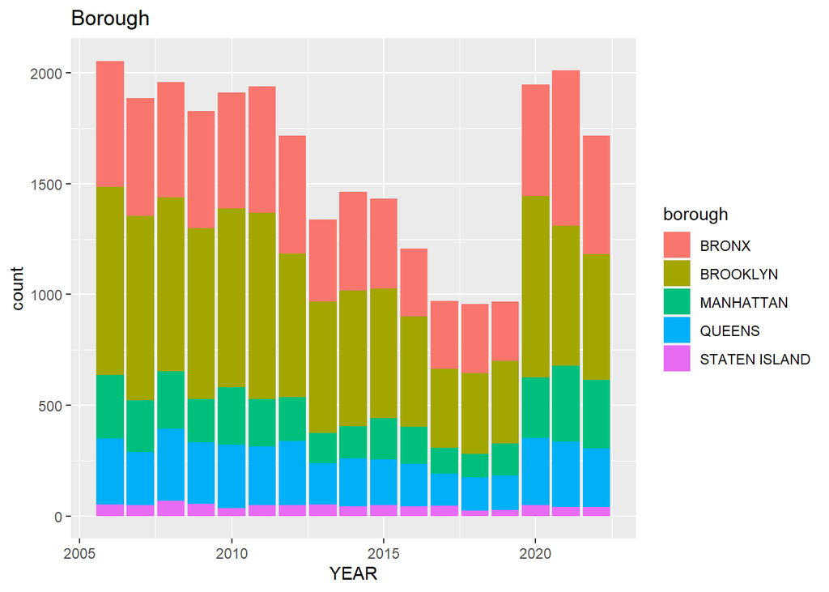

```r
nyc_cases <- read_csv(NYC_url) %>%
  select(c(OCCUR_DATE, BORO, STATISTICAL_MURDER_FLAG)) %>%
  mutate(OCCUR_DATE = mdy(OCCUR_DATE))

nyc_cases$OCCUR_DATE <- as.character(nyc_cases$OCCUR_DATE)
nyc_cases$YEAR = lubridate::year(nyc_cases$OCCUR_DATE)

nyc_cases <- nyc_cases %>%
  filter(!is.na(YEAR) & !is.na(BORO))
  ggplot(nyc_cases) +
  geom_bar(aes(x=YEAR, fill=BORO)) +
  labs(title = "Borough", fill = "borough")
```

As shown in the graph above, the shooting incidents at the boroughs are roughly ranked in the following order:

1. Brooklyn
2. Bronx
3. Queens
4. Manhattan
5. Staten Island

## Analyzing the Data

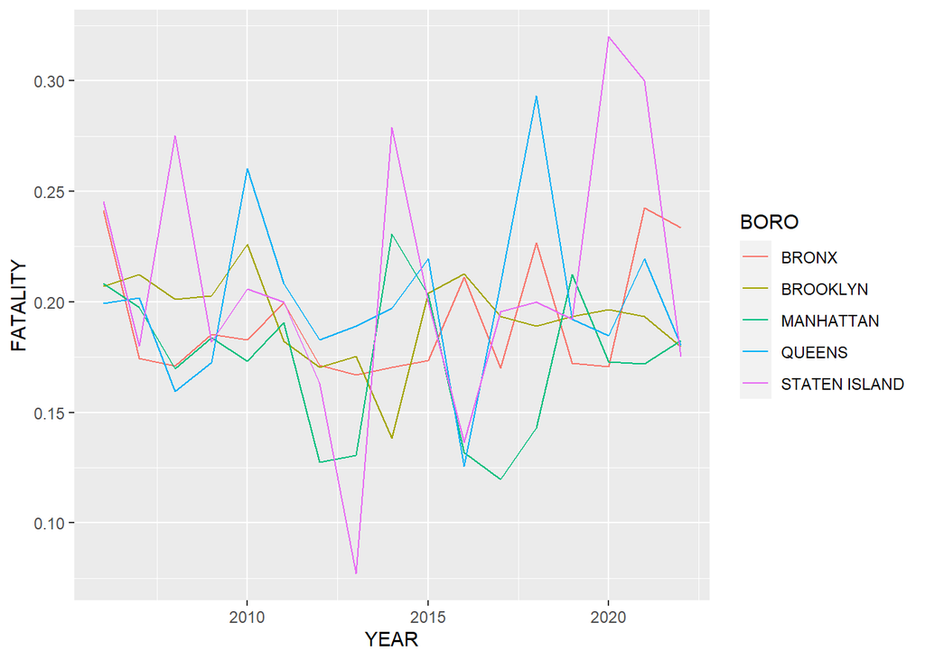

```r
nyc_murder_boro <- nyc_cases %>%
  group_by(BORO, YEAR) %>%
  summarize(TOTAL = sum(STATISTICAL_MURDER_FLAG), FATALITY =
            sum(STATISTICAL_MURDER_FLAG == "TRUE")/n()) %>%
  select(YEAR, BORO, FATALITY, TOTAL) %>%
  ungroup()


nyc_murder_boro %>%
  ggplot(aes(x = YEAR, y=FATALITY, group=BORO, color=BORO))+
  geom_line()
```

While Brooklyn has the most amount of shootings, Staten Island tend to have a higher fatality rate. However, the fatality rate of Staten Island have bigger year-over-year fluctuation compared to that of Brooklyn’s.

## Modeling the Data

```r
mod_shoot <- lm(TOTAL ~ BORO, data = nyc_murder_boro)
mod_fatality <- lm(FATALITY ~ BORO, data = nyc_murder_boro)

nyc_shoot_pred <- nyc_murder_boro %>%
  mutate(pred = predict(mod_shoot)) %>%
  ggplot() +
  geom_point(aes(x = BORO, y = TOTAL),
             color = "blue") +
  geom_point(aes(x = BORO, y = pred),
             color = "red")

nyc_fatality_pred <- nyc_murder_boro %>%
  mutate(pred = predict(mod_fatality)) %>%
  ggplot() +
  geom_point(aes(x = BORO, y = FATALITY),
             color = "blue") +
  geom_point(aes(x = BORO, y = pred),
             color = "red")
```

[output not shown]

## Conclusion

Based on the available data, Brooklyn will likely have the most amount of shootings in a given year whereas Staten Island will have the highest fatality rate from said shooting.

One Possible source of bias is the data collection process. Since these data are recorded by NYPD, there might be some inherent biases regarding the safety (or lack thereof) of certain neighborhoods which may skew the results.

Likewise, another possible source of bias is during the conclusion process. Just looking at the number, one may be led to believe that Brooklyn and Staten Island are more dangerous. However, some data that aren’t available are the number of hospitals and the proximity of the hospitals to the shooting incidents. Perhaps, Staten Island has a higher fatality rate due to either a lack of hospitals or the distance from the incident locations to the hospitals are much greater.